# Homework 8

Debi Gonzalez

2025-11-18

1. Using a t.test(), examine whether Child Behavior Checklist (CBCL) anxiety scores are different, on average, between males and females. For this question, first state the null and alternate hypothesis. Then conduct the appropriate test in R (using the suggested command). Print the command and the output. Then state the conclusion based on the test result.

Null Hypothesis: Male Anxiety mean == Female Anxiety mean  
The mean CBCL anxiety score for males equals the mean CBCL anxiety score for females.

Alternate Hypothesis: Male Anxiety mean =/= Female Anxiety mean  
The mean CBCL anxiety score differs between males and females.

Test: Two Independent Samples

```r
# Independent samples t-test comparing CBCL anxiety scores by sex
mosaic::t.test(cbcl_anxiety_t ~ birthsex, data = cbcl)
```

```
##
##  Welch Two Sample t-test
##
## data:  cbcl_anxiety_t by birthsex
## t = -0.87519, df = 96.88, p-value = 0.3836
## alternative hypothesis: true difference in means between group F and group M is not equal to 0
## 95 percent confidence interval:
##  -3.529229  1.369229
## sample estimates:
## mean in group F mean in group M
##           53.32           54.40
```

Conclusion: Because p > .05, we fail to reject the null hypothesis. There is no statistically significant difference in average CBCL anxiety scores between males and females. A Welch two-sample t-test indicated that CBCL anxiety T-scores did not differ significantly between females (M = 53.32) and males (M = 54.40), t(96.88) = –0.88, p = .38. We therefore fail to reject the null hypothesis.

2. Using a t.test(), examine whether CBCL anxiety scores are different, on average, from the clinical cutoff of 69. Are these children significantly more anxious than the standard cutoff? For this question, first state the null and alternate hypothesis. Then conduct the appropriate test in R (using the suggested command). Print the command and the output. Then state the conclusion based on the test result.

Null Hypothesis: Sample Mean == 69  
The mean CBCL anxiety score is equal to the clinical cutoff of 69.

Alternate Hypothesis: Sample mean =/= 69  
The mean CBCL anxiety score is not equal to the clinical cutoff of 69.

Test: One Sample T-Test

```r
# One sample t-test, using the clinical cutoff as the mean to compare it to:
t.test(cbcl$cbcl_anxiety_t, mu = 69)
```

```
##
##  One Sample t-test
##
## data:  cbcl$cbcl_anxiety_t
## t = -24.567, df = 99, p-value < 2.2e-16
## alternative hypothesis: true mean is not equal to 69
## 95 percent confidence interval:
##  52.63717 55.08283
## sample estimates:
## mean of x
##     53.86
```

Conclusion: Because p < .05, we reject the null hypothesis. There is a statistically significant difference in average CBCL anxiety scores in this sample and the clinical cutoff of 69. Participants’ CBCL anxiety T-scores are significantly lower than 69, on average. The actual sample mean is around 53.9, and the entire confidence interval lies well below 69. This provides strong evidence that the true anxiety level in your sample is not only different from 69—it’s much lower.

3. Is there an association between age in months and CBCL anxiety scores? One way to answer this question is to conduct a linear regression. The command in R is lm(), which stands for linear model. For this question, there is no need to state the null and alternate hypothesis, and no need to state a conclusion.

Try putting the model into an object, and then summary() the object. Then plot the graph as below.

library(car) model1 <- lm(cbcl_anxiety_t ~ agemonths, data = cbcl_data) summary(model1) avPlots(model1)

Print the output here (the summary and the plot). Ignore the intercept for now. Note the output for agemonths has 1) an estimate (in this case, it is the slope of the regression line); 2) a standard error of the estimate; 3) a t value; 4) a p value.

```r
# adding the suggested code to build the model and show the results summary and plot.

library(car)
model1 <- lm(cbcl_anxiety_t ~ agemonths, data = cbcl)

summary(model1)
```

```
##
## Call:
## lm(formula = cbcl_anxiety_t ~ agemonths, data = cbcl)
##
## Residuals:
##    Min     1Q Median     3Q    Max
## -4.743 -3.868 -2.838  1.984 24.619
##
## Coefficients:
##             Estimate Std. Error t value Pr(>|t|)
## (Intercept) 59.08311    6.40941   9.218 6.02e-15 ***
## agemonths   -0.04019    0.04909  -0.819    0.415
## ---
## Signif. codes:  0 '***' 0.001 '**' 0.01 '*' 0.05 '.' 0.1 ' ' 1
##
## Residual standard error: 6.173 on 98 degrees of freedom
## Multiple R-squared:  0.006793,   Adjusted R-squared:  -0.003341
## F-statistic: 0.6703 on 1 and 98 DF,  p-value: 0.4149
```

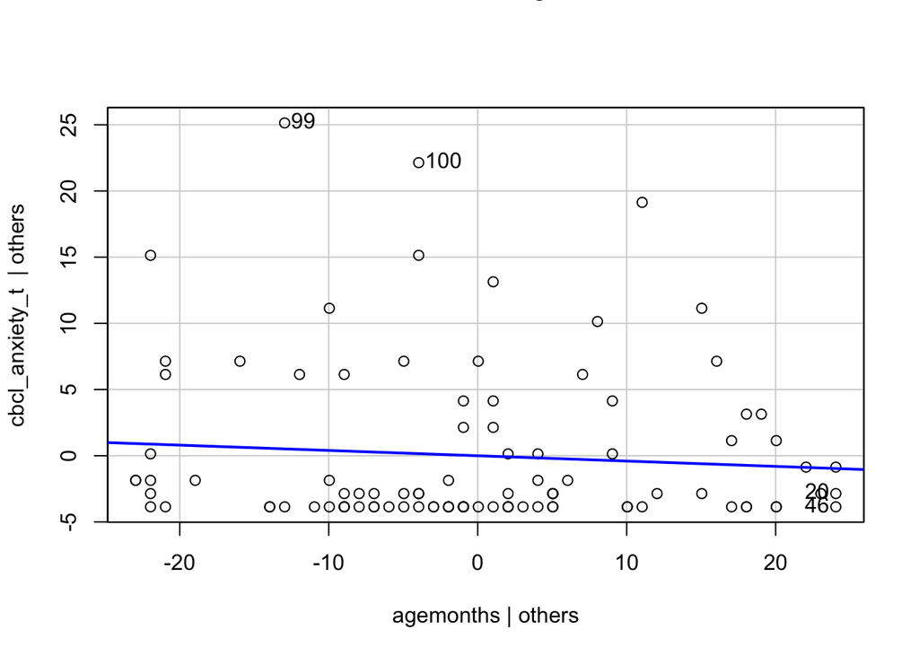

```r
avPlots(model1)
```

Now, a) take the value of the slope and subtract zero from the that value (i.e., slope – 0). Print that value here. This shows how different the slope is from zero (i.e., is it different from a flat line having no slope? The null hypothesis would be that the slope (B) = 0);

```r
-0.04019-0
```

```
## [1] -0.04019
```

2. Take that difference score and divide it by the standard error from the output. Print that value here.

```r
-0.04019/0.04909
```

```
## [1] -0.8187003
```

3. Compare that value to the t statistic from the output. Are they the same or different?

We manually calculated the t-statistic t = (estimate − null value)/standard error. Once rounded, the numbers match exactly (-0.819).

4. Using a t.test(), examine whether Child Behavior Checklist (CBCL) anxiety scores are different, on average, between males and females, but this time turn off the Welch correction (put var.equal = TRUE). You can just paste the R command and output here (no need to state the null hypothesis etc.).

```r
# Independent samples t-test comparing CBCL anxiety scores by sex with "equal variances"; omiting the Welch correction

mosaic::t.test(cbcl_anxiety_t ~ birthsex, data = cbcl, var.equal = TRUE)
```

```
##
##  Two Sample t-test
##
## data:  cbcl_anxiety_t by birthsex
## t = -0.87519, df = 98, p-value = 0.3836
## alternative hypothesis: true difference in means between group F and group M is not equal to 0
## 95 percent confidence interval:
##  -3.528875  1.368875
## sample estimates:
## mean in group F mean in group M
##           53.32           54.40
```

5. Now try examining the same hypothesis for question 4, but this time use the linear model. The command is:

model2 <- lm(cbcl_anxiety_t ~ birthsex, data = cbcl_data) summary(model2) avPlots(model2)

Paste the R output here.

```r
model2 <- lm(cbcl_anxiety_t ~ birthsex, data = cbcl)
summary(model2)
```

```
##
## Call:
## lm(formula = cbcl_anxiety_t ~ birthsex, data = cbcl)
##
## Residuals:
##    Min     1Q Median     3Q    Max
##  -4.40  -3.40  -3.32   1.91  24.60
##
## Coefficients:
##             Estimate Std. Error t value Pr(>|t|)
## (Intercept)  53.3200     0.8726  61.106   <2e-16 ***
## birthsexM     1.0800     1.2340   0.875    0.384
## ---
## Signif. codes:  0 '***' 0.001 '**' 0.01 '*' 0.05 '.' 0.1 ' ' 1
##
## Residual standard error: 6.17 on 98 degrees of freedom
## Multiple R-squared:  0.007755,   Adjusted R-squared:  -0.00237
## F-statistic: 0.766 on 1 and 98 DF,  p-value: 0.3836
```

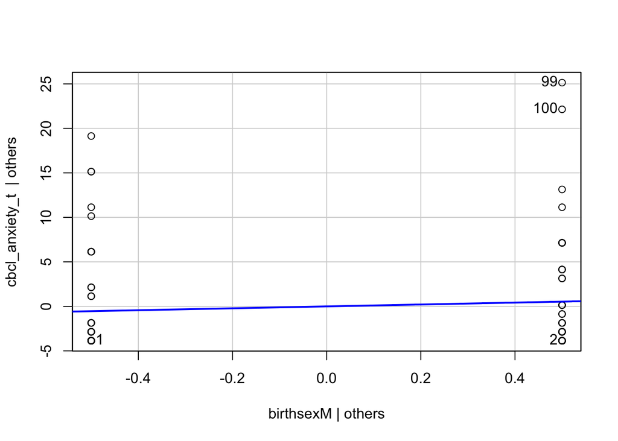

```r
avPlots(model2)
```

First examine the plot. Compare that plot to the one examining age in months as the predictor. Note the predictor is categorical for birth sex, whereas age in months is continuous.

Now, compare the linear model output with the output in question 4. Specifically, compare:

1. Calculate the mean difference for males and females from the t.test() output. Compare that with the value of the slope from the linear model. Print both here.

```r
# Based on the t-test, the female mean is 53.32 and male mean is 54.40
# The difference
54.40-53.32
```

```
## [1] 1.08
```

```r
# The slope of the linear model is 1.0800.
```

The difference of means between males and females in the t.test output and the slope of the linear model of the relationship between birth sex and CBCL anxiety score are the same (1.08).

2. Compare the t value and p value from the t.test() output to the t value and p value from the linear model output. Print both here.

T-Test Values t = -0.87519, p-value = 0.3836

Linear Model Values t= 0.875, p-value: 0.3836

The values match! I believe the flipped signs have to do with the way the t-test ordered the categorical variables in its formula.

3. Take the square root of the F-statistic from the linear model output. Compare it to the t value from both the t.test() and the linear model output. Print all three here.

```r
# the f-statistic is 0.766

# taking square root
sqrt(0.766)
```

```
## [1] 0.8752143
```

T-Test Values t = -0.87519

Linear Model Values t= 0.875

These values all match when rounded to third decimal place!

4. Compare the group differences between males and females on the CBCL anxiety scores using an Analysis of Variance (ANOVA). The command in R is aov() and uses the same formula interface you have been using.

So, paste the following into R:

model3 <- aov(cbcl_anxiety_t ~ birthsex, data = cbcl_data) summary(model3)

```r
# Creating the anova model as provided
model3 <- aov(cbcl_anxiety_t ~ birthsex, data = cbcl)
summary(model3)
```

```
##             Df Sum Sq Mean Sq F value Pr(>F)
## birthsex     1     29   29.16   0.766  0.384
## Residuals   98   3731   38.07
```

Compare the F and p values for the ANOVA with the F and p values from the linear model. Print both here.

Linear Model F-statistic: 0.766 on 1 and 98 DF, p-value: 0.3836

Anova F Value: 0.766; p-value: 0.384

Once again, the values align!

6. Now, using the same logic, conduct an ANOVA, but this time instead of birth sex, use age group as the predictor. Is there a statistically significant difference among the age groups for CBCL anxiety scores? Print your conclusion and the R output here.

```r
model4 <- aov(cbcl_anxiety_t ~ agegroup, data = cbcl)
summary(model4)
```

```
##             Df Sum Sq Mean Sq F value Pr(>F)
## agegroup     4    122    30.5   0.796   0.53
## Residuals   95   3638    38.3
```

There is no statistically significant difference in CBCL anxiety T-scores across age groups F(4,95)=0.796,p=.53.

7. Finally, conduct the same analysis as in 6), but use the linear model. Print the output and the plot here.

```r
model5 <- lm(cbcl_anxiety_t ~ agegroup, data = cbcl)
summary(model5)
```

```
##
## Call:
## lm(formula = cbcl_anxiety_t ~ agegroup, data = cbcl)
##
## Residuals:
##    Min     1Q Median     3Q    Max
## -5.647 -3.359 -2.818  1.444 25.167
##
## Coefficients:
##                  Estimate Std. Error t value Pr(>|t|)
## (Intercept)       53.3590     0.9909  53.848   <2e-16 ***
## agegroupnine       1.4592     2.1127   0.691    0.491
## agegroupten        0.4744     1.6055   0.295    0.768
## agegroupthirteen  -1.8034     2.2884  -0.788    0.433
## agegrouptwelve     2.2881     1.7985   1.272    0.206
## ---
## Signif. codes:  0 '***' 0.001 '**' 0.01 '*' 0.05 '.' 0.1 ' ' 1
##
## Residual standard error: 6.188 on 95 degrees of freedom
## Multiple R-squared:  0.03244,    Adjusted R-squared:  -0.008295
## F-statistic: 0.7964 on 4 and 95 DF,  p-value: 0.5304
```

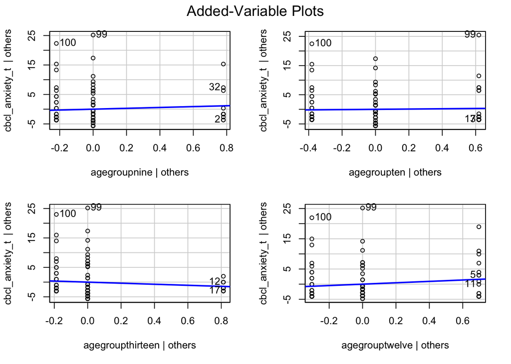

```r
avPlots(model5)
```

None of the p-values are significant, so no age group differs significantly from the reference group. The linear model confirms that there are no statistically significant differences in CBCL anxiety T-scores across age groups, F(4,95)=0.796,p=.53.